# R Basics

Kristen Bystrom

September 21, 2019

| Topics Covered | Min |
| --- | --- |
| Features of RStudio | 5 |
| Working with Packages and Libraries | 5 |
| Understanding Functions | 5 |
| Reading Data | 5 |
| Beginner Visualization | 10 |
| Bonus Highlight: Learn how to make R rap to you! | 10 |

### Features of RStudio

- R/ R Studio/ Jupyter / R Studio Cloud
- Workspace
- Console
- Editor
- R Markdown
- Running Code Chunks
- Environment
- Files/ Plots/ Packages/ **Help**/ Viewer

### Working with Packages and Libraries

When you install R, it comes with some basic capabilities. However, R is an **open source** language which means that anybody can make **packages** that add extra features you can use. There are two steps to use these packages.

1. Install the **package** onto your computer (you only need to do this once)

```r
#install.packages("ggplot2")
```

2. Load the **library** in your current R session (you need to do this for every new R program you write and should have this code in your library)

```r
library(ggplot2)
```

### Understanding Functions

You have already seen **functions**! They look like a word followed by a set of soft brackets like library(), read.csv(), sum(), or c(). The word before the soft brackets describes what the function does, and you may need to add **arguments** inside the brackets to help give the expressions information they need to operate.

Let’s try some functions!

The c() function creates a vector which can store one kind of data so you can use it later. The arguments it takes are data observations

```r
myNumericVector <- c(2,3,7,8,10)
myCharacterVector <- c("Blue", "Blue", "Red", "Red", "Red")

myNumericVector
```

```
## [1]  2  3  7  8 10
```

```r
myCharacterVector
```

```
## [1] "Blue" "Blue" "Red"  "Red"  "Red"
```

The sum() function adds up all the arguments

```r
sum(2, 2)
```

```
## [1] 4
```

```r
sum(2,3,7,8,10)
```

```
## [1] 30
```

```r
sum(myNumericVector)
```

```
## [1] 30
```

### Reading Data

One of the main ways people use R is to work with data to do visualization or statistical analysis. To do this, it’s best to put the data file in the same folder as your **R Project**, and then use a function to read it in to your R Session.

```r
myData <- read.csv("totally_normal_data.csv", header = FALSE)
```

The head() function is helpful to see what the data looks like. So is the str() function.

```r
head(myData, n = 10)
```

```
##         V1      V2
## 1  55.3846 97.1795
## 2  51.5385 96.0256
## 3  46.1538 94.4872
## 4  42.8205 91.4103
## 5  40.7692 88.3333
## 6  38.7179 84.8718
## 7  35.6410 79.8718
## 8  33.0769 77.5641
## 9  28.9744 74.4872
## 10 26.1538 71.4103
```

```r
str(myData)
```

```
## 'data.frame':    142 obs. of  2 variables:
##  $ V1: num  55.4 51.5 46.2 42.8 40.8 ...
##  $ V2: num  97.2 96 94.5 91.4 88.3 ...
```

Rename the columns to something descriptive.

```r
colnames(myData) <- c("Beyonce", "Khaled")
```

### Beginner Visualization

Let’s see what the data looks like. Remember, you may need to **install** the **package** first before **loading** the **library**.

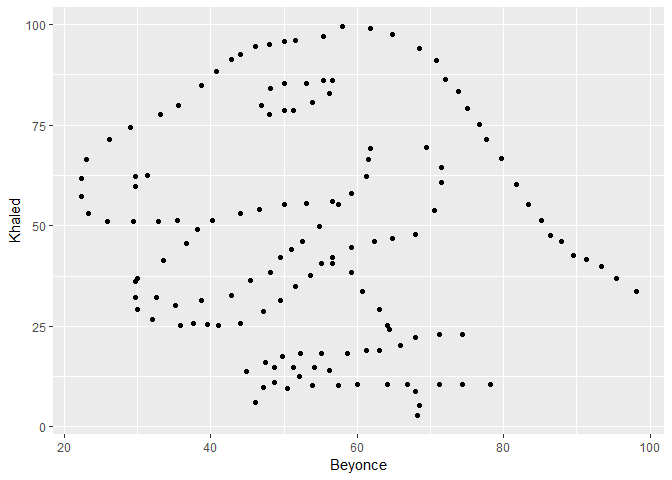

```r
# install.packages("ggplot2")

library(ggplot2)

ggplot(myData, aes(x = Beyonce, y = Khaled))+
  geom_point()
```

Credit for the dataset to: https://cran.r-project.org/web/packages/datasauRus/vignettes/Datasaurus.html

We can do a lot better than that!

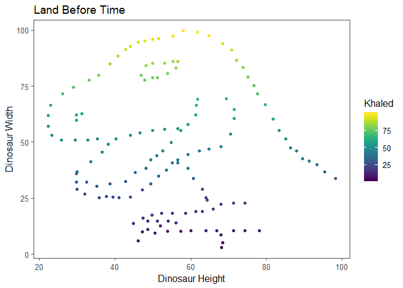

```r
# install.packages("ggplot2")

library(ggplot2)
library(ggthemes)
library(viridis)
ggplot(myData, aes(x = Beyonce, y = Khaled, color = Khaled))+
  geom_point()+
  ggtitle("Land Before Time")+
  xlab("Dinosaur Height")+
  ylab("Dinosaur Width")+
  theme_few()+scale_color_viridis()
```

### Bonus Highlight: Learn how to make R rap to you!

So why is R the best programming language? Well let me show you a few of my favourite things:

I often use the beepr package in R which has handy ringtones and short songs that can play when your code finishes executing.

However, R also has a library called BRRR

```r
if(!require(devtools)) {install.packages('devtools')}
devtools::install_github("brooke-watson/BRRR")
## Skipping install of 'BRRR' from a github remote, the SHA1 (ca4026f4) has not changed since last install.
##   Use `force = TRUE` to force installation
library(BRRR)
```

Let’s test it!

```r
skrrrahh(sound = 26)
```

```r
skrrrahh("snoop")
```

```r
skrrrahh(10)
```

You can also change your options so DJ Kaled consoles you every time you hit an error message

```r
options(error = function() {skrrrahh(34)})
```